# Nanofish: SOD activity

# Set up environment

## Load libraries

## Load functions

## Load data

### Adjust classes and transformations

```
'data.frame':   467 obs. of  30 variables:
 $ StudyID             : Factor w/ 59 levels "2","3","4","5",..: 40 40 50 50 50 50 16 16 16 7 ...
 $ StudyCluster        : Factor w/ 34 levels "1","2","3","5",..: 4 4 5 5 5 5 4 4 4 18 ...
 $ Study               : Factor w/ 59 levels "Ašmonaitė et al., 2020",..: 1 1 2 2 2 2 3 3 3 4 ...
 $ Year                : int  2020 2020 2018 2018 2018 2018 2020 2020 2020 2019 ...
 $ EScluster           : Factor w/ 101 levels "1","2","3","4",..: 1 1 2 2 2 2 3 3 3 4 ...
 $ AdministrationRoute : Factor w/ 6 levels "Food","Injection",..: 1 1 4 4 4 4 1 1 1 4 ...
 $ Concentration_mg_L  : num  NA NA 0.26 0.69 0.26 0.69 NA NA NA 20 ...
 $ ParticleMaterial    : Factor w/ 6 levels "Aminoplast","PE",..: 5 2 1 1 1 1 2 2 2 5 ...
 $ Species             : Factor w/ 20 levels "Argyrosomus regius",..: 9 9 8 8 8 8 9 9 9 7 ...
 $ ParticleShape       : Factor w/ 4 levels "Irregular","Sphere",..: 2 2 2 2 2 2 2 2 2 2 ...
 $ Sex                 : Factor w/ 4 levels "F","F:M","M",..: 4 4 4 4 4 4 4 4 4 NA ...
 $ DevelopmentalStage  : Factor w/ 5 levels "Embrio","Larva",..: 4 4 4 4 4 4 4 4 4 2 ...
 $ ExposureDurationCat : Factor w/ 3 levels "15 days +","5-15 days",..: 2 2 3 3 3 3 1 1 1 3 ...
 $ ExposureDurationDays: int  14 14 4 4 4 4 28 28 28 2 ...
```

[output cut: 16 more lines]

### Calculate Effect Size

```r
df_original <- metafor::escalc(measure = "SMD", n1i = n_treat, n2i = n_ctrl, m1i = mean_treat,
    m2i = mean_ctrl, sd1i = STD_treat, sd2i = STD_ctrl, data = df_original, vtype = "UB")
write.csv(df_original, file = "mvMetaAnalysis_SMDs.csv")
```

### Create variables

```r
outcome <- as.character(outcomeslist[[n_outcome]])

mRF <- list()  # random effects formula investigation models
mRE <- list()  # random effects multilevel models
mMR <- list()  # multilevel metaregression models

colormap <- c(Embrio = "khaki", Larva = "lightgreen", Juvenile = "lightskyblue",
    Adult = "salmon", Unclear = "plum", ExposureDurationDays = "cornflowerblue",
    ParticleSizeMean = "chartreuse4", Concentration_mg_L = "#fa0079ff", Aminoplast = "chocolate4",
    LDPE = "#2200faff", PE = "#0089faff", PET = "#00faedff", PLA = "#00fa29ff", PS = "#faf200ff",
    PVC = "#fa9a00ff", `Publication year` = "black", Variance = "navyblue")
```

### Select outcome

```
[1] "SOD activity"
```

|  | StudyID | StudyCluster | Study | Year | EScluster | AdministrationRoute | Concentration_mg_L | ParticleMaterial | Species | ParticleShape | Sex | DevelopmentalStage | ExposureDurationCat | ExposureDurationDays | ParticleSizeRange | ParticleSizeMean | ParticleSizeCat | Outcome | OutcomeCategory | Test_or_Assay | OutcomeVariable | Group | n_of_groups | n_ctrl | mean_ctrl | STD_ctrl | n_treat | mean_treat | STD_treat | … |
| --- | --- | --- | --- | --- | --- | --- | --- | --- | --- | --- | --- | --- | --- | --- | --- | --- | --- | --- | --- | --- | --- | --- | --- | --- | --- | --- | --- | --- | --- | --- |
| 104 | 59 | 1 | Estrela et al., 2021 | 2021 | 38 | Water: Static system | 0.76 | PS | Ctenopharyngodon idella | Sphere | F:M | Juvenile | up to 96h | 3 | 0.02-0.026 | 0.023 | nano | SOD activity | Neurochemical outcomes | Oxidative Stress | SOD activity | PS NP | 1 | 16 | 0.115 | 0.061 | 16 | 0.233 | 0.037 | … |
| 127 | 66 | 30 | Iheanacho &amp; Odo, 2020 | 2020 | 46 | Food |  | PVC | Clarias gariepinus | Unclear |  | Juvenile | 15 days + | 45 | 95 | 95 | micro | SOD activity | Neurochemical outcomes | Oxidative Stress | SOD activity | 0.5 | 3 | 9 | 39.92 | 3.37 | 9 | 36.1 | 2.87 | … |
| 128 | 66 | 30 | Iheanacho &amp; Odo, 2020 | 2020 | 46 | Food |  | PVC | Clarias gariepinus | Unclear |  | Juvenile | 15 days + | 45 | 95 | 95 | micro | SOD activity | Neurochemical outcomes | Oxidative Stress | SOD activity | 1.5 | 3 | 9 | 39.92 | 3.37 | 9 | 38.34 | 2.64 | … |
| 129 | 66 | 30 | Iheanacho &amp; Odo, 2020 | 2020 | 46 | Food |  | PVC | Clarias gariepinus | Unclear |  | Juvenile | 15 days + | 45 | 95 | 95 | micro | SOD activity | Neurochemical outcomes | Oxidative Stress | SOD activity | 3 | 3 | 9 | 39.92 | 3.37 | 9 | 38.66 | 3.06 | … |
| 141 | 79 | 30 | Iheanacho et al., 2020 | 2020 | 47 | Food |  | Aminoplast | Clarias gariepinus | Unclear |  | Juvenile | 15 days + | 45 | 95 | 95 | micro | SOD activity | Neurochemical outcomes | Oxidative Stress | SOD activity | MEF | 2 | 9 | 38.46 | 5.591 | 9 | 35.715 | 5.286 | … |
| 142 | 79 | 30 | Iheanacho et al., 2020 | 2020 | 47 | Food |  | PVC | Clarias gariepinus | Unclear |  | Juvenile | 15 days + | 45 | 95 | 95 | micro | SOD activity | Neurochemical outcomes | Oxidative Stress | SOD activity | PVC | 2 | 9 | 38.46 | 5.591 | 9 | 36.054 | 5.286 | … |
| 163 | 100 | 34 | Liu et al., 2019 | 2019 | 52 | Water: Static system | 0.001 | PS | Danio rerio | Sphere |  | Larva | up to 96h | 4 | 0.05-0.1 | 0.075 | nano | SOD activity | Neurochemical outcomes | Oxidative Stress | SOD activity | PS 1 µg/L | 6 | 3 | 100 | 17.771 | 3 | 92.47 | 20.181 | … |
| 164 | 100 | 34 | Liu et al., 2019 | 2019 | 52 | Water: Static system | 1 | PS | Danio rerio | Sphere |  | Larva | up to 96h | 4 | 0.05-0.1 | 0.075 | nano | SOD activity | Neurochemical outcomes | Oxidative Stress | SOD activity | PS 1 mg/L | 6 | 3 | 100 | 17.771 | 3 | 107.229 | 4.518 | … |
| 165 | 100 | 34 | Liu et al., 2019 | 2019 | 52 | Water: Static system | 0.001 | PS | Danio rerio | Sphere |  | Larva | up to 96h | 4 | 0.05-0.1 | 0.075 | nano | SOD activity | Neurochemical outcomes | Oxidative Stress | SOD activity | APS 1 µg/L | 6 | 3 | 100 | 17.771 | 3 | 112.349 | 3.916 | … |
| 166 | 100 | 34 | Liu et al., 2019 | 2019 | 52 | Water: Static system | 1 | PS | Danio rerio | Sphere |  | Larva | up to 96h | 4 | 0.05-0.1 | 0.075 | nano | SOD activity | Neurochemical outcomes | Oxidative Stress | SOD activity | APS 1 mg/L | 6 | 3 | 100 | 17.771 | 3 | 76.205 | 11.145 | … |

[output cut: 48 more lines]

# Exploratory data analysis

## Funnel plot

> Before running any meta-analytic model, it is important to explore the meta-analytic dataset to search for potential outliers that could represent data extraction errors. (Nakagawa et al. 2022)

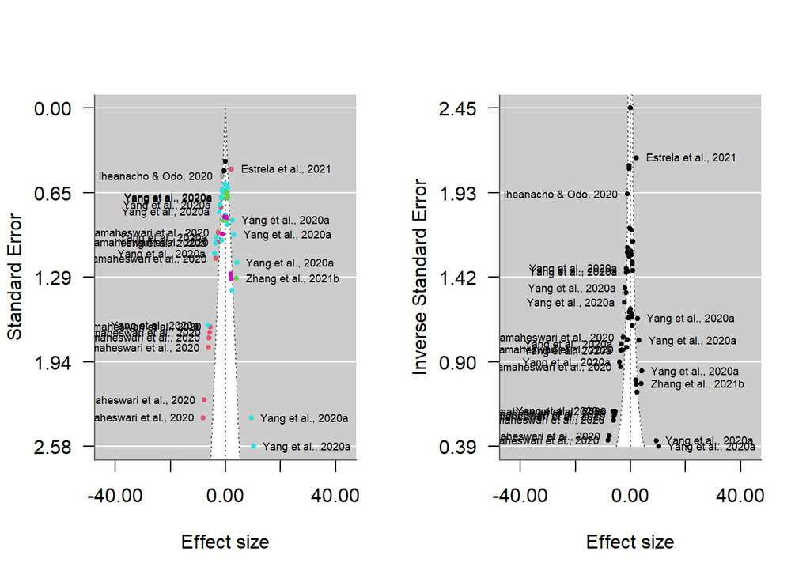

## Alluvial plot

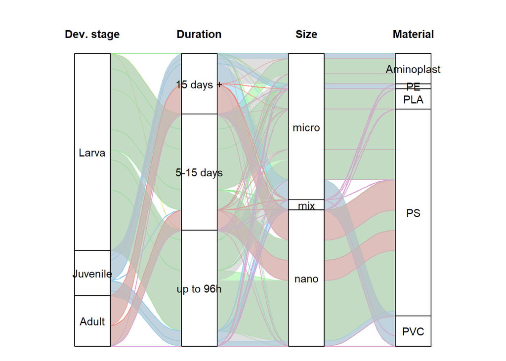

# Multilevel meta-analytic model

## Random effects formula desing

```
[1] "Considering number of studies: 14, number of ES clusters: 23 and number of independent observations of ES: 58, the random effects formula for SOD activity is: ~1 | Study/EScluster/ESid"
```

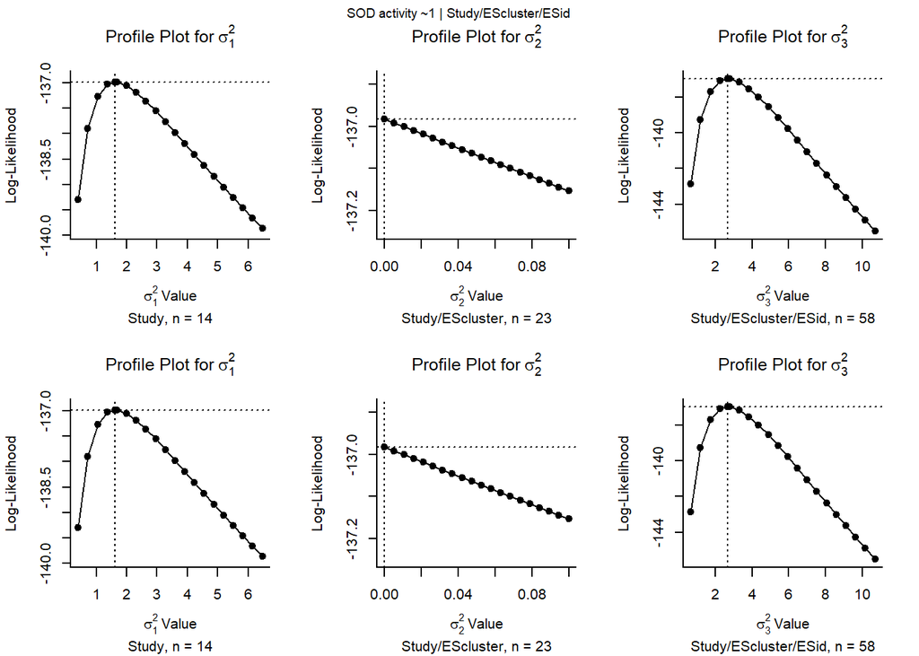

> A profile likelihood plot should show a single peak at the corresponding ML/REML estimate. If `refline=TRUE` (the default), the value of the parameter estimate is indicated by a dotted vertical line and its log-likelihood value by a dotted horizontal line. Hence, the intersection of these two lines should correspond to the peak (assuming that the model was fitted with ML/REML estimation).

> When profiling a variance component (or some other parameter that cannot be negative), the peak may be at zero (if this corresponds to the ML/REML estimate of the parameter). In this case, the profiled log-likelihood should be a monotonically decreasing function of the parameter. Similarly, when profiling a correlation component, the peak may be at -1 or +1.

> If the profiled log-likelihood has multiple peaks, this indicates that the likelihood surface is not unimodal. In such cases, the ML/REML estimate may correspond to a local optimum (when the intersection of the two dotted lines is not at the highest peak).

> If the profile is flat (over the entire parameter space or large portions of it), then this suggests that at least some of the parameters of the model are not identifiable (and the parameter estimates obtained are to some extent arbitrary). See Raue et al. (2009) for some further discussion of parameter identifiability and the use of profile likelihoods to check for this.

> The function checks whether any profiled log-likelihood value is actually larger than the log-likelihood of the fitted model (using a numerical tolerance of `lltol`). If so, a warning is issued as this might indicate that the optimizer did not identify the actual ML/REML estimate of the parameter profiled.[Viechtbauer (2022)](Viechtbauer 2010)

## Additional random effects factors

Study cluster, particle material and species as random effects term can further improve results?

## Main result: Multilevel model with $\rho = 0.5$ and robust variance estimate

```r
# Assumed correlation of rho = 0.5, except if there is only one ES by Study (no
# correlation)
if (nES == nSt) {
    VCVrho <- 0
    VCV <- df$vi
} else {
    VCVrho <- 0.5
    VCV <- vcalc(vi, cluster = interaction(df$EScluster, df$Study), obs = ESid, data = df,
        rho = VCVrho)
}

mname1 <- "ML"
mname2 <- paste0(mname1, "_RobVar")

mRE[[mname1]] <- rma.mv(yi, VCV, random = RE_formula, data = df, slab = Study, method = "REML",
    test = "t", dfs = "contain", level = 95)
mRE[[mname1]] <- additional_results(mRE[[mname1]])

mRE[[mname2]] <- robust(mRE[[mname1]], cluster = df$Study, clubSandwich = TRUE)

mRE[[mname2]] <- additional_results(mRE[[mname2]])

I2_ML_RobVar <- i2_ml(mRE[[mname2]])
# I2_ML_RobVar <- i2_ml(mRE[[mname2]], boot = 1000)

extract_report(mRE[[mname2]], outcome, RE_formula)
```

#### Diagnostics plots and results

```
Multivariate Meta-Analysis Model (k = 58; method: REML)

   logLik   Deviance        AIC        BIC       AICc
-137.9110   275.8219   283.8219   291.9941   284.5912

Variance Components:

            estim    sqrt  nlvls  fixed                factor
sigma^2.1  1.6271  1.2756     14     no                 Study
sigma^2.2  0.0000  0.0001     23     no       Study/EScluster
sigma^2.3  4.1525  2.0378     58     no  Study/EScluster/ESid

Test for Heterogeneity:
Q(df = 57) = 398.5202, p-val < .0001

Number of estimates:   58
Number of clusters:    14
Estimates per cluster: 0-18 (mean: 0.98, median: 0)

Model Results:

estimate      se¹     tval¹     df¹    pval¹    ci.lb¹   ci.ub¹
 -0.3571  0.5154   -0.6929   11.23   0.5024   -1.4886   0.7743

---
Signif. codes:  0 '***' 0.001 '**' 0.01 '*' 0.05 '.' 0.1 ' ' 1

1) results based on cluster-robust inference (var-cov estimator: CR2,
   approx t-test and confidence interval, df: Satterthwaite approx)
```

```
[1] 0.282 0.000 0.718
```

```
               I2_Total                I2_Study      I2_Study/EScluster
           9.091725e+01            2.559526e+01            1.774525e-07
I2_Study/EScluster/ESid
           6.532199e+01
```

```
$results
        % of total variance    I2
Level 1        9.082750e+00   ---
Level 2        6.532199e+01 65.32
Level 3        1.774525e-07     0
Level 4        2.559526e+01  25.6

$totalI2
[1] 90.91725

$plot
```

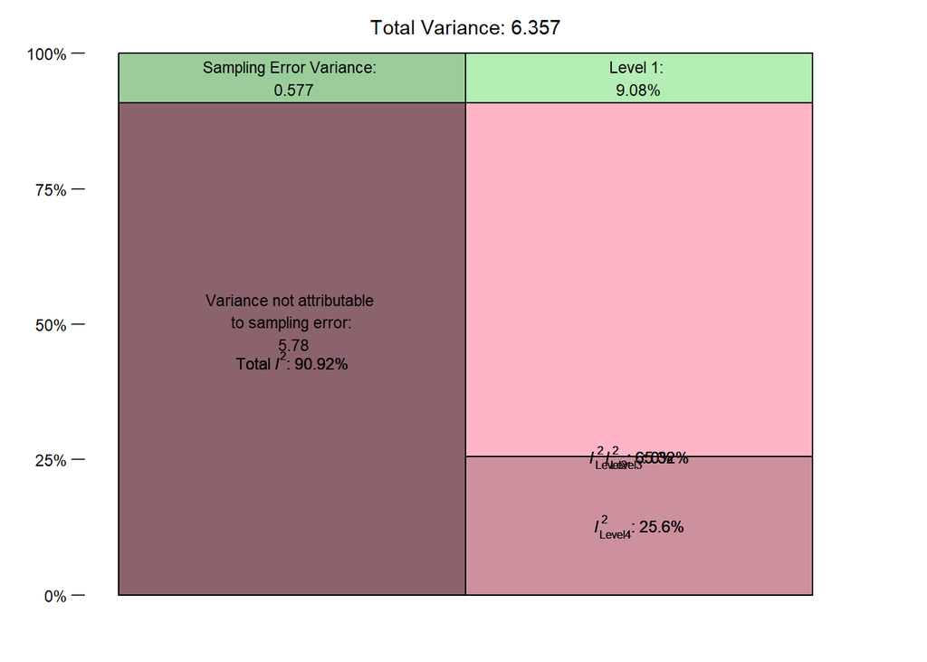

```
attr(,"class")
[1] "mlm.variance.distribution" "list"
```

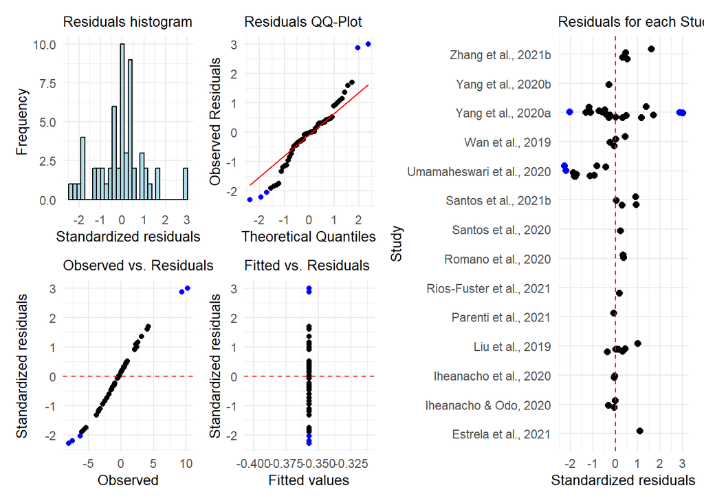

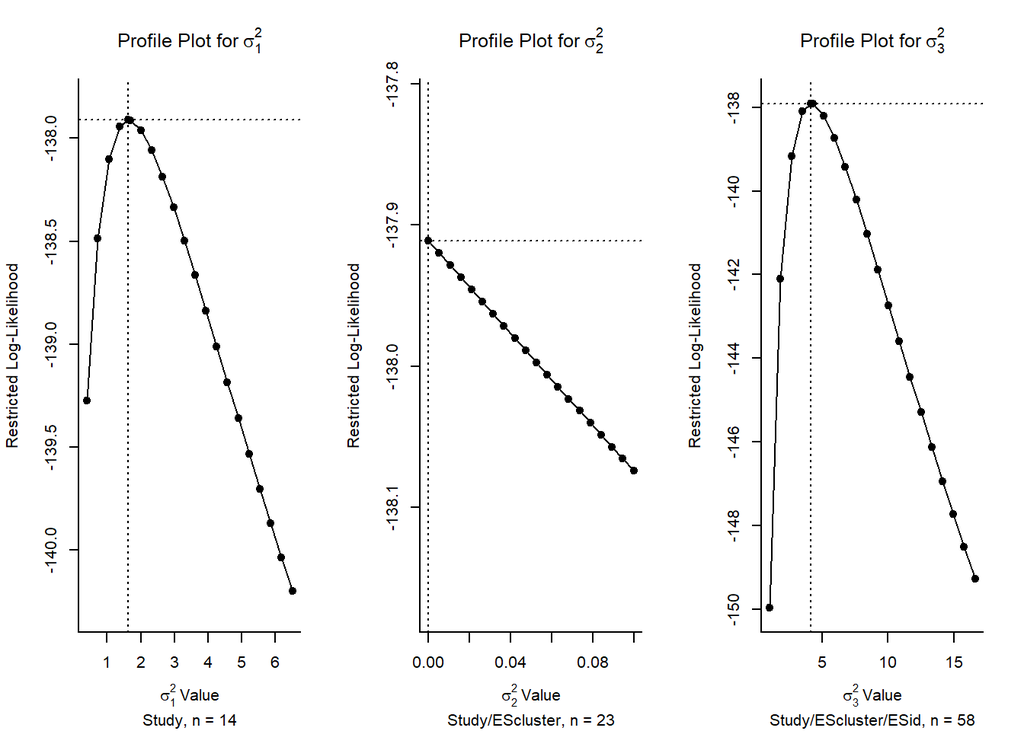

### Forest plot

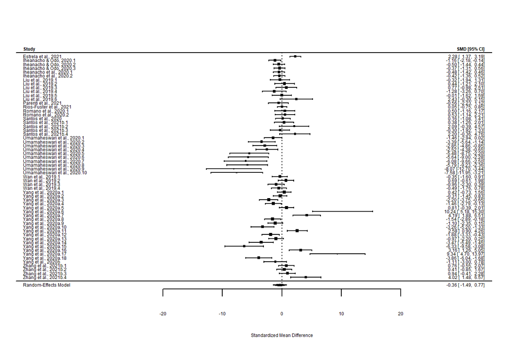

The meta-analysis comprised 58 comparisons from 23 control group clusters of 14 independent studies, so the random formula for SOD activity was ~1 | Study/EScluster/ESid.

No difference between treatment and control groups (ES = -0.3571258 ± 0.5153811, CI95% = -1.4885935 to 0.774342, predicted interval -5.754972 to 5.0407205), with high heterogeneity (i² = 90.92, Q = 398.5201802, p < 0.001 ) and variance explained by each component of $\sigma^2_{Study} = 1.63$, $\sigma^2_{EScluster} = 0.00$, $\sigma^2_{ESid} = 4.15$.

# Publication bias

> **Small-study effect:** when small studies (with small sample sizes) tend to report large effect sizes. (Yang et al. 2023)

> While the PET method works best when the true effect captured by β0β0 is **zero**, PEESE shows a better performance when the true effect is **not** zero. Stanley and Doucouliagos ([2014](https://bookdown.org/MathiasHarrer/Doing_Meta_Analysis_in_R/references.html#ref-stanley2014meta)) therefore proposed to combine both methods, in order to balance out their individual strengths. The resulting approach is the PET-PEESE method. PET-PEESE uses the intercept β0 of either PET or PEESE as the estimate of the corrected true effect.

> Whether PET or PEESE is used depends on the size of the intercept calculated by the PET method. When β0PET is significantly larger than zero in a one-sided test with α = 0.05, we use the intercept of PEESE as the true effect size estimate. If PET’s intercept is not significantly larger than zero, we remain with the PET estimate.

> In most implementations of regression models in *R*, it is conventional to test the significance of coefficients using a two-sided test (i.e. we test if a ββ weight significantly differs from zero, no matter the direction). To assume a one-sided test with α = 0.05, we already regard the intercept as significant when p < 0.1, and when the estimate of β0 is larger than zero<sup>38</sup>. (Harrer et al., n.d.)

> **Time-lag bias:** when statistically significant (“positive” results) tend to be published earlier than those with statistically non-significant findings (“negative” results), leading to a decline in reported effect sizes over time (i.e., a decline effect). (Yang et al. 2023)

> Given that high heterogeneity may invalidate publication bias test, it is best to account for the potential heterogeneity when testing publication bias. (Yang et al. 2023)

> PET-PEESE performs poorly in research areas where there are only a few studies, all studies use small samples, and where there is very high heterogeneity of results from study to study. Nonetheless, the statistical properties of conventional meta-analysis approaches are much worse than PET-PEESE under these same conditions.(Stanley 2017)

So, **better use meta-regression dataset**, but requires larger dataset to avoid possible convergence issues.

#### Plots

```
[1] "PET"
```

```
Multivariate Meta-Analysis Model (k = 58; method: REML)

   logLik   Deviance        AIC        BIC       AICc
-132.3975   264.7949   276.7949   288.8389   278.5449

Variance Components:

            estim    sqrt  nlvls  fixed                factor
sigma^2.1  2.3388  1.5293     14     no                 Study
sigma^2.2  0.0000  0.0001     23     no       Study/EScluster
sigma^2.3  3.9431  1.9857     58     no  Study/EScluster/ESid

Test for Residual Heterogeneity:
QE(df = 55) = 379.6424, p-val < .0001

Number of estimates:   58
Number of clusters:    14
Estimates per cluster: 0-18 (mean: 0.98, median: 0)

Test of Moderators (coefficients 2:3):¹
F(df1 = 2, df2 = 2.94) = 0.7593, p-val = 0.5421

Model Results:

           estimate         se¹     tval¹    df¹    pval¹       ci.lb¹
intrcpt  -1494.1507  1084.9582   -1.3772   4.68   0.2307   -4342.3008
ESSE         1.1528     3.1885    0.3615   1.94   0.7532     -12.9717
Year         0.7390     0.5370    1.3761   4.68   0.2310      -0.6706
             ci.ub¹
intrcpt  1353.9995
ESSE       15.2773
Year        2.1486

---
Signif. codes:  0 '***' 0.001 '**' 0.01 '*' 0.05 '.' 0.1 ' ' 1

1) results based on cluster-robust inference (var-cov estimator: CR2,
   approx t/F-tests and confidence intervals, df: Satterthwaite approx)
```

```
  pred   se ci.lb ci.ub  pi.lb pi.ub
 -1.33 2.28 -7.24  4.58 -10.11  7.44
```

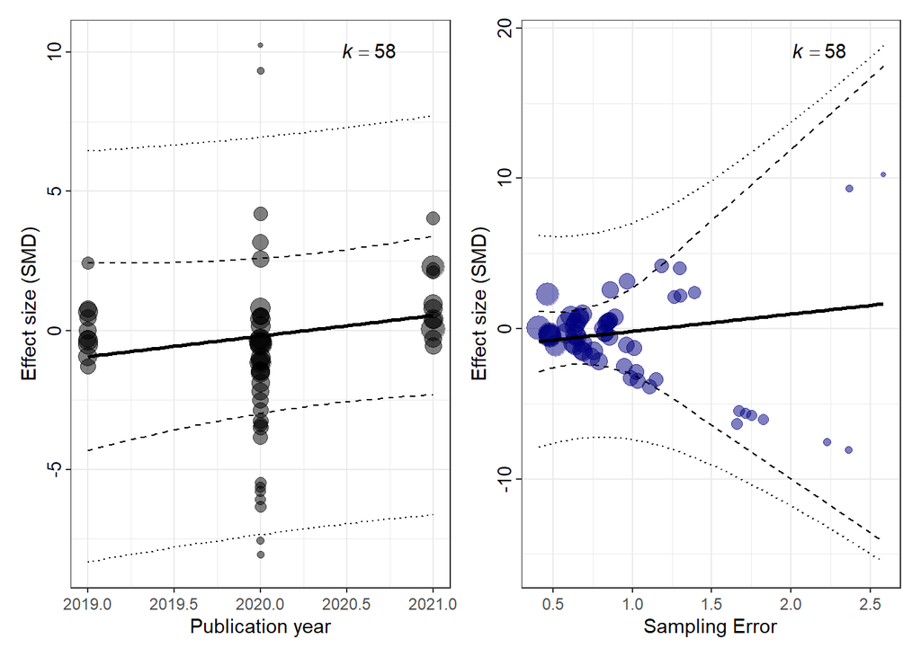

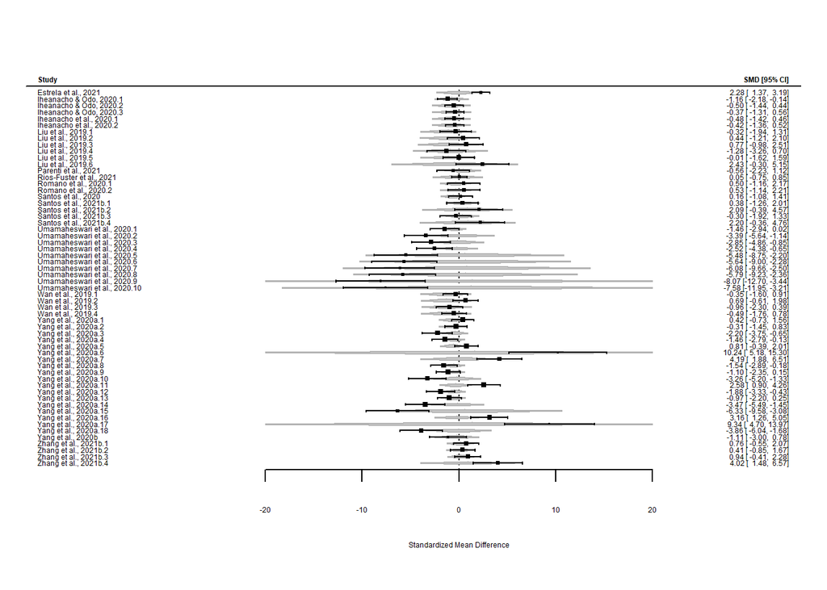

**Small-study effect** The regression slope of the extended Egger’s regression is $\sqrt{SMDSE} = 1.15276$ is it statistically different from zero?`

If p<0.050: Smaller studies (with larger sampling error) have larger effect sizes –> small-study effect exists in this dataset. Data is assymmetrically distributed in the funnel plot.

If p>=0.050 no small-study effect exists in this dataset. Smaller studies (with larger sampling error) do not have larger effect sizes –> no small-study effect exists in this dataset. Data is symmetrically distributed in the funnel plot.

If p<0.050: studies with statistically significant findings tend to be published earlier than these with “negative” results, i.e. time-lag bias exists in this dataset

If p>=0.050: studies with statistically significant findings **do not** tend to be published earlier than these with “negative” results, i.e. no time-lag bias exists in this dataset

### Sensitivity analysis: publication bias with adapted SE

> Egger’s regression and its variants suffer from low power and poor performance when there are fewer than 20 effect sizes, or when the overall effect is large. (Nakagawa et al. 2022)

> Instead of the sample size (n1 + n2), however, for a meta-analysis of SMD or lnRR, we propose using the ‘effective sample size’ because it accounts for unbalanced sampling (cf. Stanley, 2005).(Nakagawa et al. 2022)

```r
if (mRE[[bias]]$pval[2] < 0.05) {

    # calculate modified SE based on effective sample size
    df$ess_vi <- with(df, sqrt((n_treat + n_ctrl)/(n_treat * n_ctrl)))
    df$ess_SE <- sqrt(df$ess_vi)  ## sampling error for ES

    # PET + year
    bias2 <- "PET sensitivity"
    mRE[[bias2]] <- rma.mv(yi, VCV, random = RE_formula, mods = ~ess_SE + Year, data = df,
        slab = Study, method = "REML", test = "t", dfs = "contain", level = 95)
    mRE[[bias2]] <- robust(mRE[[bias2]], cluster = df$Study, clubSandwich = TRUE)
    mRE[[bias2]] <- additional_results(mRE[[bias2]])
    mRE[[bias2]][["pi"]] <- predict(mRE[[bias2]], newmods = c(0, mean(df$Year)),
        digits = 2)

    # PEESE + year
    if (mRE[[bias2]]$pval[2] < 0.1) {
        mname <- "PEESE sensitivity"
        mRE[[mname]] <- rma.mv(yi, VCV, random = RE_formula, mods = ~ess_vi + Year,
            data = df, slab = Study, method = "REML", test = "t", dfs = "contain",
            level = 95)
        mRE[[mname]] <- robust(mRE[[mname]], cluster = df$Study, clubSandwich = TRUE)
        mRE[[mname]] <- additional_results(mRE[[mname]])
        mRE[[mname]][["pi"]] <- predict(mRE[[mname]], newmods = c(0, mean(df$Year)),
            digits = 2)
        bias2 <- mname
    }
}
```

If the results are the same, indicates the robustness of the small-study test.

#### Plots

# Sensitivity

## Rho range

```r
if (VCVrho != 0) {

    rho_range <- c(0, 0.25, 0.75, 0.9)  # assume a range values of rho

    for (j in 1:length(rho_range)) {

        mname <- paste("rho", rho_range[j], sep = "_")

        VCV2 <- vcalc(vi, cluster = interaction(df$EScluster, df$Study), obs = ESid,
            data = df, rho = rho_range[j])

        mRE[[mname]] <- rma.mv(yi, VCV2, random = RE_formula, data = df, slab = Study,
            method = "REML", test = "t", dfs = "contain", level = 95)
        mRE[[mname]] <- robust(mRE[[mname]], cluster = df$Study, clubSandwich = TRUE)
        mRE[[mname]] <- additional_results(mRE[[mname]])
    }
}
```

## Leave one out + Rho range

```r
if (VCVrho != 0) {
    rho_range <- c(0.25, 0.5, 0.75, 0.9)
} else {
    rho_range <- 0
}

for (i in sort(unique(df$Study))) {

    df_temp <- df[df$Study != i, ]

    for (j in 1:length(rho_range)) {

        mname <- paste("rho", rho_range[j], "l1o", i, sep = "_")
        print(mname)
        VCV2 <- vcalc(vi, cluster = interaction(df_temp$EScluster, df_temp$Study),
            obs = ESid, data = df_temp, rho = rho_range[j])

        mRE[[mname]] <- rma.mv(yi, VCV2, random = RE_formula, data = df_temp, slab = Study,
            method = "REML", test = "t", dfs = "contain", level = 95)
        mRE[[mname]] <- robust(mRE[[mname]], cluster = df_temp$Study, clubSandwich = TRUE)
        mRE[[mname]] <- additional_results(mRE[[mname]])
    }
}
```

[output not shown]

[output cut: 41 more lines]

# Tables

|  | n studies | n ES clusters | n ES | overall effect | standard error | p-value | Lower CI | Upper CI | Lower PI | Upper PI | Q | Q p-value | $I^2$$_{total}$ | $I^2$$_{Study}$ | $I^2$$_{EScluster}$ | $I^2$$_{ES}$ | $\sigma^2$$_{Study}$ | $\sigma^2$$_{EScluster}$ | $\sigma^2$$_{ES}$ |
| --- | --- | --- | --- | --- | --- | --- | --- | --- | --- | --- | --- | --- | --- | --- | --- | --- | --- | --- | --- |
| ML | 14 | 23 | 58 | -0.36 | 0.5 | 0.4941 | -1.45 | 0.74 | -5.67 | 4.95 | 398.52 | 0 | 90.92 | 25.60 | 0.00 | 65.32 | 1.63 | 0.00 | 4.15 |
| ML_RobVar | 14 | 23 | 58 | -0.36 | 0.5 | 0.5024 | -1.49 | 0.77 | -5.75 | 5.04 | 398.52 | 0 | 90.92 | 25.60 | 0.00 | 65.32 | 1.63 | 0.00 | 4.15 |
| PET | 14 | 23 | 58 | -1494.15 | 1085.0 | 0.2307 | -4342.30 | 1354.00 | -10.11 | 7.44 | 379.64 | 0 | 91.58 | 34.10 | 0.00 | 57.49 | 2.34 | 0.00 | 3.94 |
| rho_0 | 14 | 23 | 58 | -0.27 | 0.5 | 0.5863 | -1.32 | 0.78 | -5.03 | 4.50 | 293.58 | 0 | 88.69 | 35.07 | 0.00 | 53.62 | 1.79 | 0.00 | 2.74 |
| rho_0.25 | 14 | 23 | 58 | -0.31 | 0.5 | 0.5432 | -1.40 | 0.78 | -5.35 | 4.73 | 315.81 | 0 | 89.74 | 30.29 | 0.00 | 59.46 | 1.71 | 0.00 | 3.35 |
| rho_0.75 | 14 | 23 | 58 | -0.40 | 0.5 | 0.4664 | -1.59 | 0.78 | -6.21 | 5.40 | 677.00 | 0 | 92.01 | 21.37 | 0.00 | 70.64 | 1.55 | 0.00 | 5.11 |
| rho_0.9 | 14 | 23 | 58 | -0.43 | 0.5 | 0.4472 | -1.65 | 0.78 | -6.49 | 5.62 | 1509.14 | 0 | 92.60 | 19.11 | 0.00 | 73.49 | 1.49 | 0.00 | 5.73 |
| rho_0.25_l1o_Estrela et al., 2021 | 13 | 22 | 57 | -0.44 | 0.5 | 0.4047 | -1.55 | 0.67 | -5.48 | 4.61 | 282.10 | 0 | 89.30 | 29.60 | 0.00 | 59.69 | 1.64 | 0.00 | 3.32 |
| rho_0.5_l1o_Estrela et al., 2021 | 13 | 22 | 57 | -0.48 | 0.5 | 0.3814 | -1.64 | 0.68 | -5.90 | 4.94 | 362.47 | 0 | 90.57 | 25.01 | 0.00 | 65.55 | 1.58 | 0.00 | 4.13 |
| rho_0.75_l1o_Estrela et al., 2021 | 13 | 22 | 57 | -0.52 | 0.5 | 0.3612 | -1.73 | 0.69 | -6.36 | 5.32 | 634.41 | 0 | 91.74 | 20.89 | 0.00 | 70.85 | 1.50 | 0.00 | 5.10 |
| rho_0.9_l1o_Estrela et al., 2021 | 13 | 22 | 57 | -0.55 | 0.6 | 0.3503 | -1.79 | 0.70 | -6.65 | 5.56 | 1451.66 | 0 | 92.36 | 18.68 | 0.00 | 73.68 | 1.45 | 0.00 | 5.73 |
| rho_0.25_l1o_Iheanacho & Odo, 2020 | 13 | 22 | 55 | -0.28 | 0.5 | 0.6252 | -1.49 | 0.94 | -5.68 | 5.13 | 313.05 | 0 | 90.06 | 30.68 | 0.00 | 59.38 | 1.93 | 0.00 | 3.73 |
| rho_0.5_l1o_Iheanacho & Odo, 2020 | 13 | 22 | 55 | -0.32 | 0.6 | 0.5828 | -1.58 | 0.94 | -6.07 | 5.43 | 395.41 | 0 | 91.10 | 26.35 | 0.00 | 64.75 | 1.85 | 0.00 | 4.54 |
| rho_0.75_l1o_Iheanacho & Odo, 2020 | 13 | 22 | 55 | -0.37 | 0.6 | 0.5442 | -1.68 | 0.94 | -6.51 | 5.78 | 671.37 | 0 | 92.08 | 22.39 | 0.00 | 69.69 | 1.77 | 0.00 | 5.49 |
| rho_0.9_l1o_Iheanacho & Odo, 2020 | 13 | 22 | 55 | -0.40 | 0.6 | 0.5230 | -1.74 | 0.94 | -6.79 | 5.99 | 1492.20 | 0 | 92.61 | 20.25 | 0.00 | 72.36 | 1.71 | 0.00 | 6.12 |
| rho_0.25_l1o_Iheanacho et al., 2020 | 13 | 22 | 56 | -0.30 | 0.5 | 0.5923 | -1.48 | 0.89 | -5.61 | 5.02 | 315.69 | 0 | 89.99 | 31.03 | 0.00 | 58.97 | 1.89 | 0.00 | 3.59 |
| rho_0.5_l1o_Iheanacho et al., 2020 | 13 | 22 | 56 | -0.34 | 0.6 | 0.5499 | -1.57 | 0.89 | -6.01 | 5.32 | 398.49 | 0 | 91.06 | 26.50 | 0.00 | 64.56 | 1.81 | 0.00 | 4.40 |
| rho_0.75_l1o_Iheanacho et al., 2020 | 13 | 22 | 56 | -0.39 | 0.6 | 0.5118 | -1.67 | 0.89 | -6.45 | 5.67 | 676.78 | 0 | 92.06 | 22.38 | 0.00 | 69.69 | 1.72 | 0.00 | 5.36 |
| rho_0.9_l1o_Iheanacho et al., 2020 | 13 | 22 | 56 | -0.42 | 0.6 | 0.4910 | -1.73 | 0.89 | -6.73 | 5.89 | 1506.72 | 0 | 92.61 | 20.16 | 0.00 | 72.45 | 1.66 | 0.00 | 5.98 |
| rho_0.25_l1o_Liu et al., 2019 | 13 | 22 | 52 | -0.37 | 0.6 | 0.5202 | -1.60 | 0.86 | -5.87 | 5.13 | 307.91 | 0 | 91.32 | 29.90 | 0.00 | 61.42 | 1.92 | 0.00 | 3.94 |
| rho_0.5_l1o_Liu et al., 2019 | 13 | 22 | 52 | -0.41 | 0.6 | 0.4872 | -1.69 | 0.86 | -6.27 | 5.44 | 387.48 | 0 | 92.23 | 25.47 | 0.00 | 66.76 | 1.83 | 0.00 | 4.79 |
| rho_0.75_l1o_Liu et al., 2019 | 13 | 22 | 52 | -0.46 | 0.6 | 0.4568 | -1.79 | 0.87 | -6.72 | 5.79 | 656.12 | 0 | 93.09 | 21.48 | 0.00 | 71.60 | 1.73 | 0.00 | 5.77 |
| rho_0.9_l1o_Liu et al., 2019 | 13 | 22 | 52 | -0.49 | 0.6 | 0.4401 | -1.85 | 0.87 | -6.99 | 6.01 | 1460.31 | 0 | 93.55 | 19.34 | 0.00 | 74.20 | 1.67 | 0.00 | 6.41 |
| rho_0.25_l1o_Parenti et al., 2021 | 13 | 22 | 57 | -0.30 | 0.5 | 0.5795 | -1.44 | 0.85 | -5.48 | 4.89 | 315.74 | 0 | 90.14 | 31.14 | 0.00 | 59.01 | 1.82 | 0.00 | 3.44 |
| rho_0.5_l1o_Parenti et al., 2021 | 13 | 22 | 57 | -0.34 | 0.5 | 0.5361 | -1.53 | 0.84 | -5.89 | 5.20 | 398.49 | 0 | 91.24 | 26.42 | 0.00 | 64.81 | 1.73 | 0.00 | 4.26 |
| rho_0.75_l1o_Parenti et al., 2021 | 13 | 22 | 57 | -0.39 | 0.6 | 0.4974 | -1.63 | 0.85 | -6.34 | 5.55 | 676.99 | 0 | 92.26 | 22.17 | 0.00 | 70.10 | 1.65 | 0.00 | 5.21 |
| rho_0.9_l1o_Parenti et al., 2021 | 13 | 22 | 57 | -0.42 | 0.6 | 0.4766 | -1.69 | 0.85 | -6.62 | 5.78 | 1508.66 | 0 | 92.82 | 19.89 | 0.00 | 72.93 | 1.59 | 0.00 | 5.84 |
| rho_0.25_l1o_Rios-Fuster et al., 2021 | 13 | 22 | 57 | -0.32 | 0.5 | 0.5459 | -1.47 | 0.82 | -5.52 | 4.87 | 314.84 | 0 | 89.75 | 30.96 | 0.00 | 58.79 | 1.82 | 0.00 | 3.46 |
| rho_0.5_l1o_Rios-Fuster et al., 2021 | 13 | 22 | 57 | -0.37 | 0.5 | 0.5061 | -1.56 | 0.82 | -5.92 | 5.18 | 397.13 | 0 | 90.87 | 26.27 | 0.00 | 64.60 | 1.73 | 0.00 | 4.26 |
| rho_0.75_l1o_Rios-Fuster et al., 2021 | 13 | 22 | 57 | -0.42 | 0.6 | 0.4708 | -1.66 | 0.82 | -6.37 | 5.53 | 673.84 | 0 | 91.93 | 22.02 | 0.00 | 69.91 | 1.64 | 0.00 | 5.22 |
| rho_0.9_l1o_Rios-Fuster et al., 2021 | 13 | 22 | 57 | -0.45 | 0.6 | 0.4518 | -1.72 | 0.82 | -6.65 | 5.75 | 1499.89 | 0 | 92.50 | 19.75 | 0.00 | 72.75 | 1.59 | 0.00 | 5.85 |
| rho_0.25_l1o_Romano et al., 2020 | 13 | 22 | 56 | -0.36 | 0.5 | 0.5057 | -1.53 | 0.81 | -5.63 | 4.90 | 314.15 | 0 | 90.39 | 30.66 | 0.00 | 59.73 | 1.83 | 0.00 | 3.57 |
| rho_0.5_l1o_Romano et al., 2020 | 13 | 22 | 56 | -0.41 | 0.5 | 0.4704 | -1.62 | 0.80 | -6.03 | 5.21 | 396.89 | 0 | 91.43 | 26.04 | 0.00 | 65.40 | 1.74 | 0.00 | 4.38 |
| rho_0.75_l1o_Romano et al., 2020 | 13 | 22 | 56 | -0.46 | 0.6 | 0.4390 | -1.72 | 0.81 | -6.48 | 5.56 | 674.83 | 0 | 92.42 | 21.86 | 0.00 | 70.56 | 1.65 | 0.00 | 5.33 |
| rho_0.9_l1o_Romano et al., 2020 | 13 | 22 | 56 | -0.49 | 0.6 | 0.4222 | -1.78 | 0.81 | -6.76 | 5.79 | 1505.05 | 0 | 92.94 | 19.62 | 0.00 | 73.32 | 1.59 | 0.00 | 5.96 |
| rho_0.25_l1o_Santos et al., 2020 | 13 | 22 | 57 | -0.33 | 0.5 | 0.5390 | -1.47 | 0.82 | -5.52 | 4.86 | 315.17 | 0 | 90.04 | 31.01 | 0.00 | 59.04 | 1.81 | 0.00 | 3.45 |
| rho_0.5_l1o_Santos et al., 2020 | 13 | 22 | 57 | -0.38 | 0.5 | 0.5000 | -1.56 | 0.81 | -5.92 | 5.17 | 397.68 | 0 | 91.14 | 26.29 | 0.00 | 64.85 | 1.73 | 0.00 | 4.26 |
| rho_0.75_l1o_Santos et al., 2020 | 13 | 22 | 57 | -0.42 | 0.6 | 0.4654 | -1.66 | 0.81 | -6.37 | 5.52 | 675.33 | 0 | 92.17 | 22.03 | 0.00 | 70.14 | 1.64 | 0.00 | 5.21 |
| rho_0.9_l1o_Santos et al., 2020 | 13 | 22 | 57 | -0.45 | 0.6 | 0.4468 | -1.72 | 0.82 | -6.65 | 5.74 | 1504.76 | 0 | 92.73 | 19.75 | 0.00 | 72.98 | 1.58 | 0.00 | 5.84 |
| rho_0.25_l1o_Santos et al., 2021b | 13 | 19 | 54 | -0.44 | 0.5 | 0.4318 | -1.62 | 0.74 | -5.73 | 4.86 | 307.41 | 0 | 90.63 | 29.42 | 0.00 | 61.21 | 1.76 | 0.00 | 3.66 |
| rho_0.5_l1o_Santos et al., 2021b | 13 | 19 | 54 | -0.49 | 0.6 | 0.3945 | -1.72 | 0.74 | -6.14 | 5.16 | 389.41 | 0 | 91.65 | 24.76 | 0.00 | 66.88 | 1.66 | 0.00 | 4.49 |
| rho_0.75_l1o_Santos et al., 2021b | 13 | 19 | 54 | -0.55 | 0.6 | 0.3623 | -1.83 | 0.73 | -6.60 | 5.50 | 665.47 | 0 | 92.60 | 20.58 | 0.00 | 72.01 | 1.56 | 0.00 | 5.45 |
| rho_0.9_l1o_Santos et al., 2021b | 13 | 19 | 54 | -0.58 | 0.6 | 0.3453 | -1.89 | 0.73 | -6.88 | 5.72 | 1490.96 | 0 | 93.11 | 18.35 | 0.00 | 74.76 | 1.49 | 0.00 | 6.08 |
| rho_0.25_l1o_Umamaheswari et al., 2020 | 13 | 18 | 48 | 0.03 | 0.3 | 0.9182 | -0.59 | 0.65 | -4.62 | 4.68 | 247.41 | 0 | 87.21 | 0.00 | 0.00 | 87.21 | 0.00 | 0.00 | 3.47 |
| rho_0.5_l1o_Umamaheswari et al., 2020 | 13 | 18 | 48 | 0.00 | 0.3 | 0.9897 | -0.65 | 0.66 | -5.21 | 5.22 | 343.01 | 0 | 89.79 | 0.00 | 0.00 | 89.79 | 0.00 | 0.00 | 4.48 |
| rho_0.75_l1o_Umamaheswari et al., 2020 | 13 | 18 | 48 | -0.02 | 0.3 | 0.9536 | -0.71 | 0.68 | -5.82 | 5.78 | 632.89 | 0 | 91.68 | 0.00 | 0.00 | 91.68 | 0.00 | 0.00 | 5.61 |
| rho_0.9_l1o_Umamaheswari et al., 2020 | 13 | 18 | 48 | -0.03 | 0.3 | 0.9252 | -0.74 | 0.68 | -6.18 | 6.12 | 1469.12 | 0 | 92.55 | 0.00 | 0.00 | 92.55 | 0.00 | 0.00 | 6.33 |
| rho_0.25_l1o_Wan et al., 2019 | 13 | 22 | 54 | -0.31 | 0.6 | 0.5849 | -1.54 | 0.91 | -5.78 | 5.15 | 311.48 | 0 | 90.72 | 30.54 | 0.00 | 60.18 | 1.95 | 0.00 | 3.84 |
| rho_0.5_l1o_Wan et al., 2019 | 13 | 22 | 54 | -0.36 | 0.6 | 0.5457 | -1.63 | 0.91 | -6.17 | 5.46 | 391.98 | 0 | 91.68 | 26.18 | 0.00 | 65.49 | 1.86 | 0.00 | 4.66 |
| rho_0.75_l1o_Wan et al., 2019 | 13 | 22 | 54 | -0.41 | 0.6 | 0.5101 | -1.73 | 0.92 | -6.61 | 5.80 | 663.58 | 0 | 92.58 | 22.22 | 0.00 | 70.36 | 1.78 | 0.00 | 5.62 |
| rho_0.9_l1o_Wan et al., 2019 | 13 | 22 | 54 | -0.43 | 0.6 | 0.4906 | -1.79 | 0.92 | -6.88 | 6.02 | 1474.18 | 0 | 93.07 | 20.09 | 0.00 | 72.99 | 1.72 | 0.00 | 6.24 |
| rho_0.25_l1o_Yang et al., 2020a | 13 | 20 | 40 | -0.20 | 0.4 | 0.6488 | -1.16 | 0.75 | -3.55 | 3.14 | 134.81 | 0 | 79.63 | 59.74 | 19.90 | 0.00 | 1.62 | 0.54 | 0.00 |
| rho_0.5_l1o_Yang et al., 2020a | 13 | 20 | 40 | -0.20 | 0.4 | 0.6288 | -1.06 | 0.67 | -3.18 | 2.79 | 129.12 | 0 | 75.62 | 62.81 | 5.51 | 7.30 | 1.42 | 0.12 | 0.17 |
| rho_0.75_l1o_Yang et al., 2020a | 13 | 20 | 40 | -0.23 | 0.4 | 0.5676 | -1.09 | 0.63 | -3.25 | 2.79 | 146.04 | 0 | 76.14 | 58.15 | 0.00 | 17.99 | 1.35 | 0.00 | 0.42 |
| rho_0.9_l1o_Yang et al., 2020a | 13 | 20 | 40 | -0.26 | 0.4 | 0.5267 | -1.14 | 0.62 | -3.40 | 2.88 | 221.39 | 0 | 77.50 | 53.91 | 0.00 | 23.59 | 1.32 | 0.00 | 0.58 |
| rho_0.25_l1o_Yang et al., 2020b | 13 | 22 | 57 | -0.27 | 0.5 | 0.6078 | -1.41 | 0.87 | -5.45 | 4.90 | 315.15 | 0 | 90.13 | 31.13 | 0.00 | 59.00 | 1.81 | 0.00 | 3.43 |
| rho_0.5_l1o_Yang et al., 2020b | 13 | 22 | 57 | -0.32 | 0.5 | 0.5615 | -1.51 | 0.86 | -5.86 | 5.21 | 397.98 | 0 | 91.24 | 26.44 | 0.00 | 64.80 | 1.73 | 0.00 | 4.24 |
| rho_0.75_l1o_Yang et al., 2020b | 13 | 22 | 57 | -0.37 | 0.6 | 0.5201 | -1.61 | 0.87 | -6.31 | 5.57 | 676.76 | 0 | 92.27 | 22.20 | 0.00 | 70.08 | 1.65 | 0.00 | 5.20 |
| rho_0.9_l1o_Yang et al., 2020b | 13 | 22 | 57 | -0.40 | 0.6 | 0.4978 | -1.67 | 0.87 | -6.59 | 5.79 | 1509.14 | 0 | 92.83 | 19.92 | 0.00 | 72.90 | 1.59 | 0.00 | 5.83 |
| rho_0.25_l1o_Zhang et al., 2021b | 13 | 22 | 54 | -0.47 | 0.5 | 0.3865 | -1.63 | 0.69 | -5.69 | 4.74 | 302.73 | 0 | 90.07 | 28.44 | 0.00 | 61.63 | 1.66 | 0.00 | 3.60 |
| rho_0.5_l1o_Zhang et al., 2021b | 13 | 22 | 54 | -0.52 | 0.5 | 0.3595 | -1.73 | 0.69 | -6.11 | 5.07 | 386.28 | 0 | 91.19 | 23.94 | 0.00 | 67.25 | 1.58 | 0.00 | 4.43 |
| rho_0.75_l1o_Zhang et al., 2021b | 13 | 22 | 54 | -0.57 | 0.6 | 0.3356 | -1.83 | 0.69 | -6.57 | 5.43 | 661.46 | 0 | 92.23 | 19.90 | 0.00 | 72.33 | 1.49 | 0.00 | 5.41 |
| rho_0.9_l1o_Zhang et al., 2021b | 13 | 22 | 54 | -0.60 | 0.6 | 0.3228 | -1.89 | 0.69 | -6.86 | 5.66 | 1485.85 | 0 | 92.79 | 17.75 | 0.00 | 75.04 | 1.43 | 0.00 | 6.04 |

|  | ML | ML_RobVar | PET | rho_0 | rho_0.25 | rho_0.75 | rho_0.9 | rho_0.25_l1o_Estrela.et.al...2021 | rho_0.5_l1o_Estrela.et.al...2021 | rho_0.75_l1o_Estrela.et.al...2021 | rho_0.9_l1o_Estrela.et.al...2021 | rho_0.25_l1o_Iheanacho...Odo..2020 | rho_0.5_l1o_Iheanacho...Odo..2020 | rho_0.75_l1o_Iheanacho...Odo..2020 | rho_0.9_l1o_Iheanacho...Odo..2020 | rho_0.25_l1o_Iheanacho.et.al...2020 | rho_0.5_l1o_Iheanacho.et.al...2020 | rho_0.75_l1o_Iheanacho.et.al...2020 | rho_0.9_l1o_Iheanacho.et.al...2020 | rho_0.25_l1o_Liu.et.al...2019 | rho_0.5_l1o_Liu.et.al...2019 | rho_0.75_l1o_Liu.et.al...2019 | rho_0.9_l1o_Liu.et.al...2019 | rho_0.25_l1o_Parenti.et.al...2021 | rho_0.5_l1o_Parenti.et.al...2021 | rho_0.75_l1o_Parenti.et.al...2021 | rho_0.9_l1o_Parenti.et.al...2021 | rho_0.25_l1o_Rios.Fuster.et.al...2021 | rho_0.5_l1o_Rios.Fuster.et.al...2021 | … |
| --- | --- | --- | --- | --- | --- | --- | --- | --- | --- | --- | --- | --- | --- | --- | --- | --- | --- | --- | --- | --- | --- | --- | --- | --- | --- | --- | --- | --- | --- | --- |
| logLik: | -137.9109713395203 | -137.9109713395203 | -132.3974729673889 | -134.7963361251393 | -136.2585831327227 | -139.6187955310482 | -140.6349165782602 | -133.8249642578661 | -135.4761037823725 | -137.1768447866335 | -138.1858912977894 | -130.984813541941 | -132.4327489341604 | -133.9306502230932 | -134.8246001029502 | -132.7566484858358 | -134.2722435673568 | -135.8391661764651 | -136.7731726901248 | -124.7967766312198 | -126.1598008714773 | -127.5543974709346 | -128.3816039125039 | -134.4351764607919 | -136.0324861189037 | -137.6808803730511 | -138.6613897451657 | -134.4755660888065 | -136.0640616124891 | … |
| deviance: | 275.8219426790406 | 275.8219426790406 | 264.7949459347777 | 269.5926722502786 | 272.5171662654453 | 279.2375910620964 | 281.2698331565203 | 267.6499285157322 | 270.9522075647451 | 274.353689573267 | 276.3717825955787 | 261.9696270838821 | 264.8654978683207 | 267.8613004461865 | 269.6492002059003 | 265.5132969716717 | 268.5444871347137 | 271.6783323529302 | 273.5463453802496 | 249.5935532624396 | 252.3196017429546 | 255.1087949418691 | 256.7632078250078 | 268.8703529215838 | 272.0649722378074 | 275.3617607461021 | 277.3227794903314 | 268.951132177613 | 272.1281232249781 | … |
| AIC: | 283.8219426790406 | 283.8219426790406 | 276.7949459347777 | 277.5926722502786 | 280.5171662654453 | 287.2375910620964 | 289.2698331565203 | 275.6499285157322 | 278.9522075647451 | 282.353689573267 | 284.3717825955787 | 269.9696270838821 | 272.8654978683207 | 275.8613004461865 | 277.6492002059003 | 273.5132969716717 | 276.5444871347137 | 279.6783323529302 | 281.5463453802496 | 257.5935532624396 | 260.3196017429545 | 263.1087949418692 | 264.7632078250078 | 276.8703529215838 | 280.0649722378074 | 283.3617607461021 | 285.3227794903314 | 276.951132177613 | 280.1281232249781 | … |
| BIC: | 291.9941477503788 | 291.9941477503788 | 288.8389450461726 | 285.7648773216168 | 288.6893713367836 | 295.4097961334347 | 297.4420382278586 | 283.7513352786728 | 287.0536143276857 | 290.4550963362076 | 292.4731893585193 | 277.9255632701392 | 280.8214340545778 | 283.8172366324436 | 285.6051363921574 | 281.5426297126015 | 284.5738198756436 | 287.70766509386 | 289.5756781211795 | 265.3208557933369 | 268.0469042738519 | 270.8360974727664 | 272.4905103559051 | 284.9717596845244 | 288.166379000748 | 291.4631675090427 | 293.424186253272 | 285.0525389405536 | 288.2295299879187 | … |
| AICc: | 284.5911734482714 | 284.5911734482714 | 278.5449459347777 | 278.3619030195094 | 281.2863970346761 | 288.0068218313272 | 290.0390639257511 | 276.4342422412224 | 279.7365212902353 | 283.1380032987572 | 285.156096321069 | 270.7859536144943 | 273.681824398933 | 276.6776269767987 | 278.4655267365126 | 274.3132969716717 | 277.3444871347137 | 280.4783323529302 | 282.3463453802497 | 258.4631184798309 | 261.1891669603459 | 263.9783601592604 | 265.6327730423991 | 277.654666647074 | 280.8492859632976 | 284.1460744715923 | 286.1070932158216 | 277.7354459031032 | 280.9124369504684 | … |

# Influential cases

> Outliers and influential cases can actually reveal patterns that may lead to new insights about study characteristics that could be acting as potential moderators (Viechtbauer and Cheung 2010)

Cook’s distance: examine what effect the deletion of the ith study has on the fitted values of all k studies simultaneously (Viechtbauer and Cheung 2010)

DFBETAS: directly examine the influence of deleting the ith case on each individual parameter estimate (Viechtbauer and Cheung 2010)

So if a point has high Cook’s Distance, use DFBETAS to identify witch estimate is mainly influenced (only makes sense for meta regression).

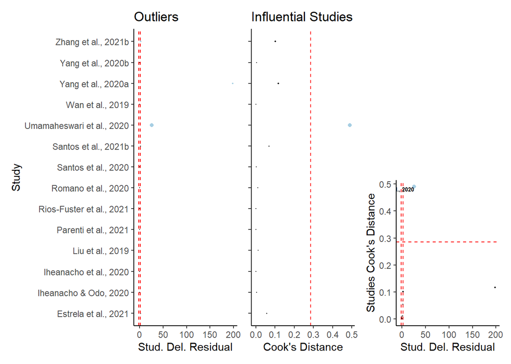

```r
influentialcases_plots(mRE, "ML_RobVar", "ML", 3)
```

# Multilevel meta-regression

SYRCLE PROTOCOL: Meta-regression will be used for outcomes with at least 10 experiments.

> The minimal number of studies or effect sizes required by a multilevel meta-regression remains unknown, albeit some simulation studies suggest that the estimates of model coefficients of a multilevel meta-regression are generally stable under various simulated situations.(Yang et al. 2023) … the complexity of parameterization of such a meta-regression requires a large dataset to make optimization algorithms free of convergence issues.(Yang et al. 2023)

## Model 1: Size, Duration, Development

```r
df_MR <- select(df, c("Year", "StudyID", "Study", "EScluster", "ESid", "DevelopmentalStage",
    "ExposureDurationDays", "ParticleSizeMean", "yi", "vi"))

mname1 <- "Base"
mname2 <- paste0(mname1, "_RobVar")

# are there differences between the different forms of DevelopmentalStage?
# mods_formula <- formula(~ ParticleSizeMean +
# ExposureDurationDays*DevelopmentalStage) at least one of the
# DevelopmentalStage levels is different than zero?
if (n_outcome != 10) {
    mods_formula <- formula(~0 + ParticleSizeMean + ExposureDurationDays * DevelopmentalStage)
} else if (n_outcome == 10) {
    # for Sensory-motor function
    mods_formula <- formula(~0 + ParticleSizeMean + ExposureDurationDays)
}

mMR[[mname1]] <- rma.mv(yi, VCV, random = RE_formula, mods = mods_formula, data = df_MR,
    slab = Study, method = "REML", test = "t", dfs = "contain", level = 95)  #it will only keep complete cases

nSt_MR <- mMR[[mname1]]$s.nlevels[1]  # number of studies
nEC_MR <- mMR[[mname1]]$s.nlevels[2]  # number of ESclusters
nES_MR <- mMR[[mname1]]$s.nlevels[3]  # number of independent ES

print(paste0("Number of studies: ", nSt_MR, ", number of ES clusters: ", nEC_MR,
    " and number of independent observations of ES: ", nES_MR))
```

```
[1] "Number of studies: 13, number of ES clusters: 22 and number of independent observations of ES: 56"
```

```r
mMR[[mname2]] <- robust(mMR[[mname1]], cluster = df_MR$Study, clubSandwich = TRUE,
    verbose = TRUE)

mMR[[mname2]][["i2"]] <- i2_ml(mMR[[mname2]])
mMR[[mname2]][["icc"]] <- round(mMR[[mname2]]$sigma2/sum(mMR[[mname2]]$sigma2), 3)

if (n_outcome != 10) {
    anova(mMR[[mname2]], btt = c("DevelopmentalStage", "ExposureDurationDays", "ParticleSizeMean"))
} else if (n_outcome == 10) {
    # for Sensory-motor function
    anova(mMR[[mname2]], btt = c("ExposureDurationDays", "ParticleSizeMean"))
}
```

```
                  spec coefs       Fval df1   df2   pval
1   DevelopmentalStage   3:7     0.0000   5 -0.02     NA
2 ExposureDurationDays 2,6:7 11915.3369   3  0.76 0.0202 *
3     ParticleSizeMean     1     0.2326   1  1.17 0.7044
```

The meta-regression comprised 56 comparisons from 22 control group clusters of 13 independent studies.

#### Diagnostics plots

```
Multivariate Meta-Analysis Model (k = 56; method: REML)

   logLik   Deviance        AIC        BIC       AICc
-113.8487   227.6975   247.6975   266.6157   253.4870

Variance Components:

            estim    sqrt  nlvls  fixed                factor
sigma^2.1  0.0000  0.0001     13     no                 Study
sigma^2.2  0.0000  0.0001     22     no       Study/EScluster
sigma^2.3  4.2069  2.0511     56     no  Study/EScluster/ESid

Test for Residual Heterogeneity:
QE(df = 49) = 308.6571, p-val < .0001

Number of estimates:   56
Number of clusters:    13
Estimates per cluster: 0-18 (mean: 0.95, median: 0)

Test of Moderators (coefficients 1:7):¹
F(df1 = 7, df2 = 0) = 0.0000, p-val = NA

Model Results:

                                                 estimate      se¹       tval¹
ParticleSizeMean                                  -0.0024  0.0050     -0.4823
ExposureDurationDays                              -0.2013  0.0006   -360.0165
DevelopmentalStageLarva                           -0.3639  0.1850     -1.9668
DevelopmentalStageJuvenile                         2.2991  1.1614      1.9796
DevelopmentalStageAdult                           -0.5961  0.0646     -9.2264
ExposureDurationDays:DevelopmentalStageLarva       0.2720  0.0831      3.2730
ExposureDurationDays:DevelopmentalStageJuvenile    0.1418  0.0228      6.2144
                                                   df¹    pval¹     ci.lb¹
ParticleSizeMean                                 1.17   0.7044    -0.0480
ExposureDurationDays                                1   0.0018    -0.2084
DevelopmentalStageLarva                          1.48   0.2310    -1.5004
DevelopmentalStageJuvenile                       1.02   0.2932   -11.6654
DevelopmentalStageAdult                             1   0.0687    -1.4170
ExposureDurationDays:DevelopmentalStageLarva     1.84   0.0914    -0.1166
ExposureDurationDays:DevelopmentalStageJuvenile  2.14   0.0211     0.0496
                                                   ci.ub¹
ParticleSizeMean                                  0.0432
ExposureDurationDays                             -0.1942   **
DevelopmentalStageLarva                           0.7726
DevelopmentalStageJuvenile                       16.2636
DevelopmentalStageAdult                           0.2248    .
ExposureDurationDays:DevelopmentalStageLarva      0.6607    .
ExposureDurationDays:DevelopmentalStageJuvenile   0.2340    *

---
Signif. codes:  0 '***' 0.001 '**' 0.01 '*' 0.05 '.' 0.1 ' ' 1

1) results based on cluster-robust inference (var-cov estimator: CR2,
   approx t/F-tests and confidence intervals, df: Satterthwaite approx)
```

|  | ML | REML |
| --- | --- | --- |
| ll | -126.4213 | -113.8487 |
| dev | 176.3208 | 227.6975 |
| AIC | 272.8426 | 247.6975 |
| BIC | 293.0961 | 266.6157 |
| AICc | 277.7315 | 253.4870 |

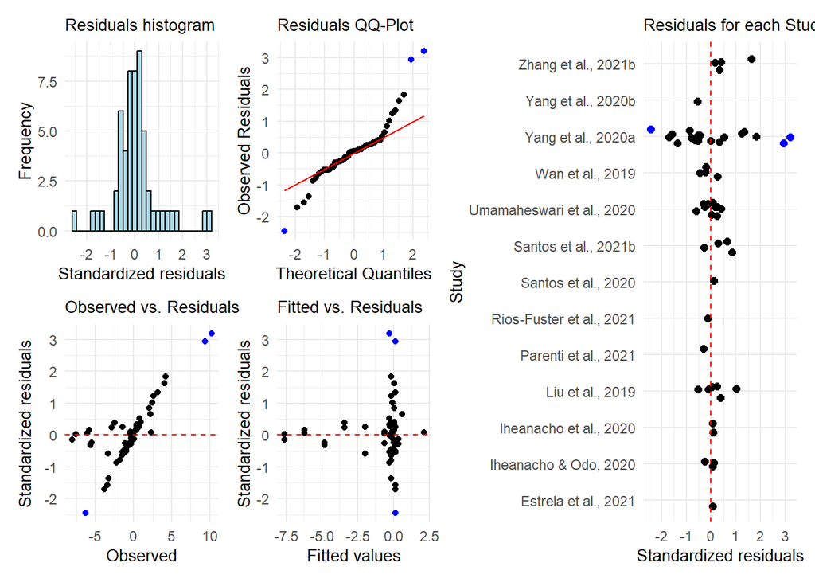

#### Influential cases

```
     Estrela et al., 2021     Iheanacho & Odo, 2020    Iheanacho et al., 2020
             3.275152e+08              4.582864e+09              2.141914e+09
         Liu et al., 2019      Parenti et al., 2021  Rios-Fuster et al., 2021
             8.575143e+09              3.980925e+08              3.275151e+08
      Santos et al., 2020      Santos et al., 2021b Umamaheswari et al., 2020
             4.734102e+08              2.742507e+09                        NA
         Wan et al., 2019        Yang et al., 2020a        Yang et al., 2020b
             6.720864e+09              9.951856e+13              2.451063e+08
      Zhang et al., 2021b
             1.031733e+09
```

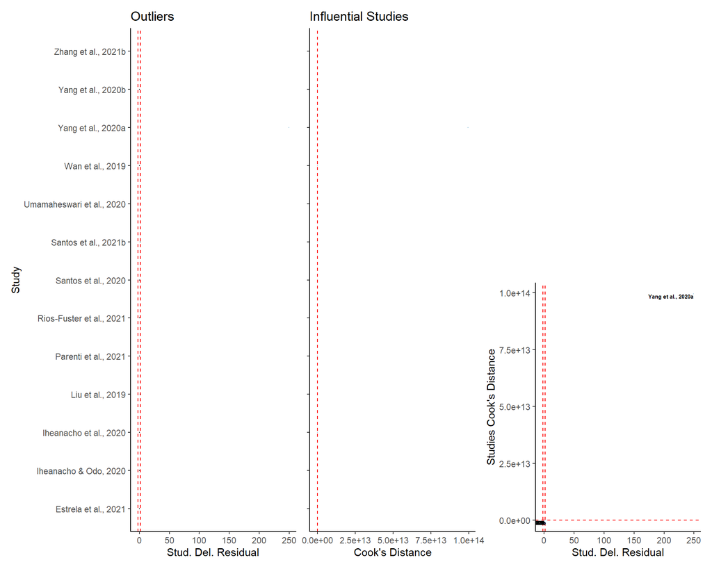

#### Orchard plots

(Nakagawa et al. 2021)

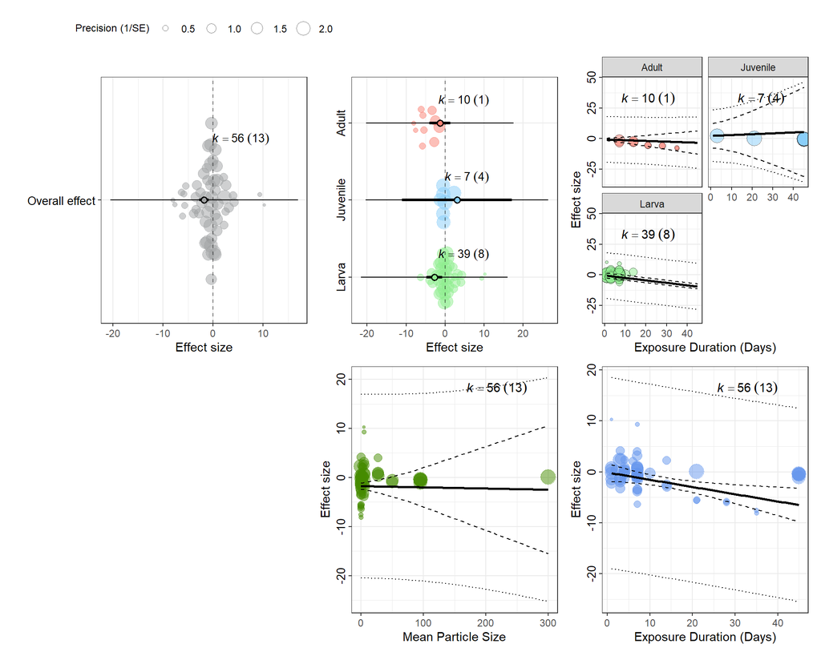

## Model 2: + Concentration

```r
df_MR <- select(df, c("Year", "StudyID", "Study", "EScluster", "ESid", "DevelopmentalStage",
    "ExposureDurationDays", "ParticleSizeMean", "Concentration_mg_L", "yi", "vi"))

mname1 <- "Conc+"
mname2 <- paste0(mname1, "_RobVar")

if (n_outcome != 10) {
    mods_formula <- formula(~0 + ParticleSizeMean + Concentration_mg_L + ExposureDurationDays *
        DevelopmentalStage)
} else if (n_outcome == 10) {
    # for Sensory-motor function for Sensory-motor function
    mods_formula <- formula(~0 + ParticleSizeMean + Concentration_mg_L + ExposureDurationDays)
}

mMR[[mname1]] <- rma.mv(yi, VCV, random = RE_formula, mods = mods_formula, data = df_MR,
    slab = Study, method = "REML", test = "t", dfs = "contain", level = 95)  #it will only keep complete cases

nSt_MR <- mMR[[mname1]]$s.nlevels[1]  # number of studies
nEC_MR <- mMR[[mname1]]$s.nlevels[2]  # number of ESclusters
nES_MR <- mMR[[mname1]]$s.nlevels[3]  # number of independent ES

print(paste0("Number of studies: ", nSt_MR, ", number of ES clusters: ", nEC_MR,
    " and number of independent observations of ES: ", nES_MR))
```

```
[1] "Number of studies: 10, number of ES clusters: 19 and number of independent observations of ES: 50"
```

```r
# mMR[[mname2]] <- robust(mMR[[mname1]], cluster = df_MR$Study, clubSandwich =
# TRUE,verbose=TRUE)
mMR[[mname2]] <- mMR[[mname1]]

mMR[[mname2]][["i2"]] <- i2_ml(mMR[[mname2]])
mMR[[mname2]][["icc"]] <- round(mMR[[mname2]]$sigma2/sum(mMR[[mname2]]$sigma2), 3)

if (n_outcome != 10) {
    anova(mMR[[mname2]], btt = c("DevelopmentalStage", "ExposureDurationDays", "ParticleSizeMean",
        "Concentration_mg_L"))
} else if (n_outcome == 10) {
    # for Sensory-motor function
    anova(mMR[[mname2]], btt = c("ExposureDurationDays", "ParticleSizeMean", "Concentration_mg_L"))
}
```

```
                  spec coefs   Fval df1 df2   pval
1   DevelopmentalStage   4:7 1.4035   4   3 0.4065
2 ExposureDurationDays   3,7 2.2729   2   3 0.2507
3     ParticleSizeMean     1 0.0051   1   3 0.9475
4   Concentration_mg_L     2 2.1585   1   3 0.2381
```

The meta-regression comprised 50 comparisons from 19 control group clusters of 10 independent studies.

#### Diagnostics plots

```r
m <- mMR[[mname2]]

summary(m)
```

```
Multivariate Meta-Analysis Model (k = 50; method: REML)

   logLik   Deviance        AIC        BIC       AICc
-102.1922   204.3845   224.3845   241.9965   231.2595

Variance Components:

            estim    sqrt  nlvls  fixed                factor
sigma^2.1  0.0000  0.0001     10     no                 Study
sigma^2.2  0.0000  0.0000     19     no       Study/EScluster
sigma^2.3  4.8443  2.2010     50     no  Study/EScluster/ESid

Test for Residual Heterogeneity:
QE(df = 43) = 299.1482, p-val < .0001

Test of Moderators (coefficients 1:7):
F(df1 = 7, df2 = 3) = 4.4122, p-val = 0.1250

Model Results:

                                              estimate      se     tval  df
ParticleSizeMean                                0.0024  0.0329   0.0714  43
Concentration_mg_L                              0.1507  0.1026   1.4692  43
ExposureDurationDays                           -0.2012  0.0945  -2.1288  12
DevelopmentalStageLarva                        -0.3278  0.8699  -0.3768   3
DevelopmentalStageJuvenile                      2.7691  2.2689   1.2205   3
DevelopmentalStageAdult                        -0.6125  1.9663  -0.3115   3
ExposureDurationDays:DevelopmentalStageLarva    0.2197  0.1830   1.2007  12
                                                pval    ci.lb   ci.ub
ParticleSizeMean                              0.9434  -0.0641  0.0688
Concentration_mg_L                            0.1491  -0.0562  0.3576
ExposureDurationDays                          0.0547  -0.4072  0.0047  .
DevelopmentalStageLarva                       0.7314  -3.0962  2.4406
DevelopmentalStageJuvenile                    0.3095  -4.4515  9.9896
DevelopmentalStageAdult                       0.7758  -6.8700  5.6450
ExposureDurationDays:DevelopmentalStageLarva  0.2530  -0.1790  0.6184

---
Signif. codes:  0 '***' 0.001 '**' 0.01 '*' 0.05 '.' 0.1 ' ' 1
```

```r
m$fit.stats
```

|  | ML | REML |
| --- | --- | --- |
| ll | -115.3073 | -102.1922 |
| dev | 155.1437 | 204.3845 |
| AIC | 250.6145 | 224.3845 |
| BIC | 269.7347 | 241.9965 |
| AICc | 256.2555 | 231.2595 |

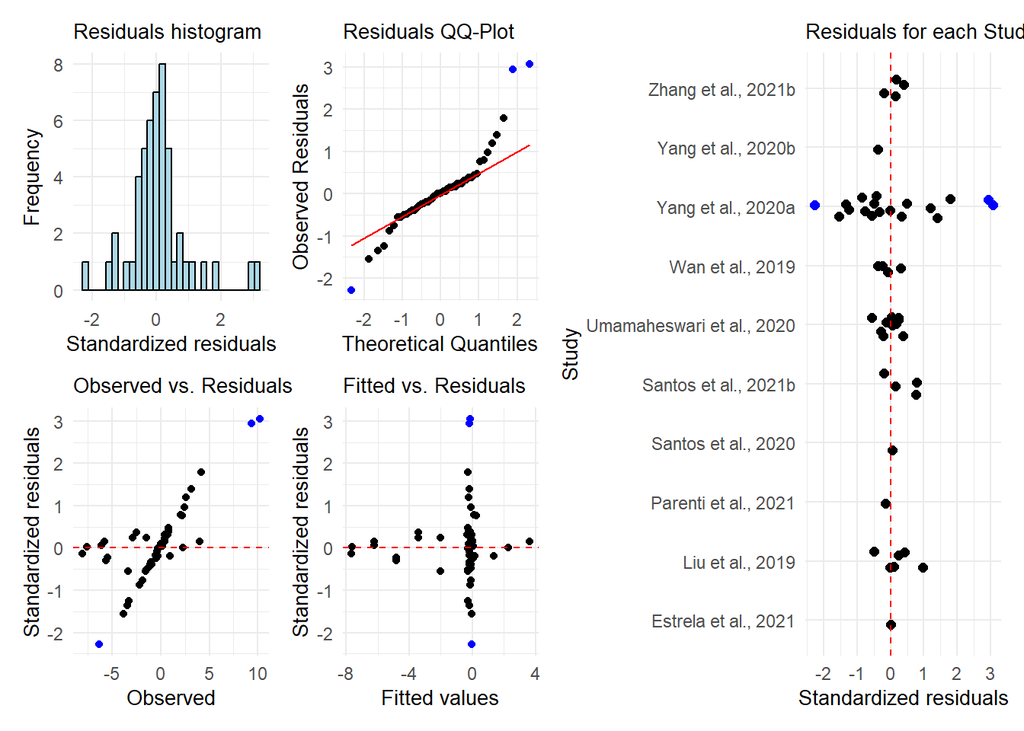

```r
diagnostic_plots(m)
```

#### Influential cases

```
     Estrela et al., 2021          Liu et al., 2019      Parenti et al., 2021
                       NA              0.0129018176              0.0029741219
      Santos et al., 2020      Santos et al., 2021b Umamaheswari et al., 2020
             0.0001537235              1.0072595040                        NA
         Wan et al., 2019        Yang et al., 2020a        Yang et al., 2020b
             2.2728895019              0.5469464356              0.0103903325
      Zhang et al., 2021b
             0.9784527126
```

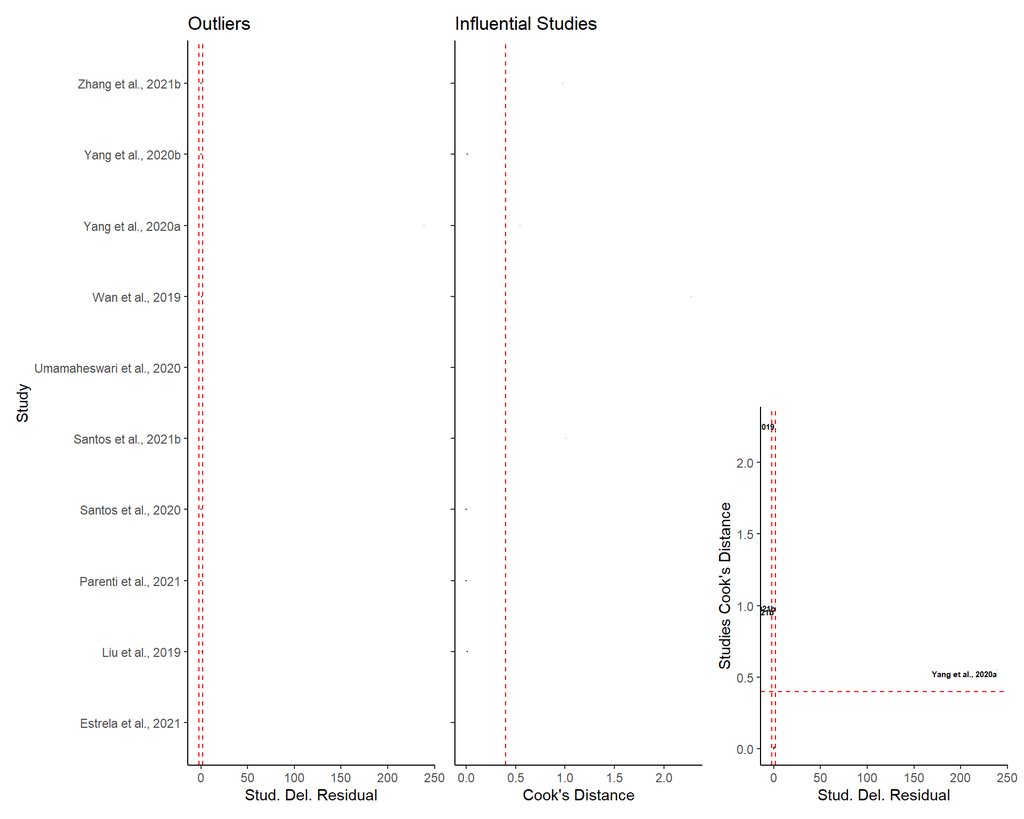

## Model 3: + ParticleMaterial

```r
df_MR <- select(df, c("Year", "StudyID", "Study", "EScluster", "ESid", "DevelopmentalStage",
    "ExposureDurationDays", "ParticleSizeMean", "ParticleMaterial", "yi", "vi"))

mname1 <- "PartMat+"
mname2 <- paste0(mname1, "_RobVar")

if (n_outcome != 10) {
    mods_formula <- formula(~(ParticleSizeMean + ExposureDurationDays * DevelopmentalStage +
        ParticleMaterial))
} else if (n_outcome == 10) {
    # for Sensory-motor function
    mods_formula <- formula(~(ParticleSizeMean + ExposureDurationDays + ParticleMaterial))
}

mMR[[mname1]] <- rma.mv(yi, VCV, random = RE_formula, mods = mods_formula, data = df_MR,
    slab = Study, method = "REML", test = "t", dfs = "contain", level = 95)  #it will only keep complete cases

nSt_MR <- mMR[[mname1]]$s.nlevels[1]  # number of studies
nEC_MR <- mMR[[mname1]]$s.nlevels[2]  # number of ESclusters
nES_MR <- mMR[[mname1]]$s.nlevels[3]  # number of independent ES

print(paste0("Number of studies: ", nSt_MR, ", number of ES clusters: ", nEC_MR,
    " and number of independent observations of ES: ", nES_MR))
```

```
[1] "Number of studies: 13, number of ES clusters: 22 and number of independent observations of ES: 56"
```

```r
mMR[[mname2]] <- robust(mMR[[mname1]], cluster = df_MR$Study, clubSandwich = TRUE,
    verbose = TRUE)
```

```
Error in Wald_testing(C_mat = constraints, beta = beta, vcov = vcov, test = test,  :
  Variance-covariance matrix of the contrast is not positive definite. The test cannot be computed.
```

```r
mMR[[mname2]][["i2"]] <- i2_ml(mMR[[mname2]])
mMR[[mname2]][["icc"]] <- round(mMR[[mname2]]$sigma2/sum(mMR[[mname2]]$sigma2), 3)

if (n_outcome != 10) {
    anova(mMR[[mname2]], btt = c("DevelopmentalStage", "ExposureDurationDays", "ParticleSizeMean",
        "ParticleMaterial"))
} else if (n_outcome == 10) {
    # for Sensory-motor function
    anova(mMR[[mname2]], btt = c("ExposureDurationDays", "ParticleSizeMean", "ParticleMaterial"))
}
```

```
                  spec     coefs       Fval df1   df2   pval
1   DevelopmentalStage 4:5,10:11     0.0000   4 -0.61     NA
2 ExposureDurationDays   3,10:11 11145.6647   3  0.63 0.0386 *
3     ParticleSizeMean         2     0.0038   1  1.33 0.9586
4     ParticleMaterial       6:9     0.0000   4 -0.11     NA
```

The meta-regression comprised 56 comparisons from 22 control group clusters of 13 independent studies.

#### Diagnostics plots

```r
m <- mMR[[mname2]]

summary(m)
```

```
Multivariate Meta-Analysis Model (k = 56; method: REML)

   logLik   Deviance        AIC        BIC       AICc
-105.6433   211.2866   239.2866   264.5799   253.2866

Variance Components:

            estim    sqrt  nlvls  fixed                factor
sigma^2.1  0.0000  0.0001     13     no                 Study
sigma^2.2  0.0000  0.0000     22     no       Study/EScluster
sigma^2.3  4.4626  2.1125     56     no  Study/EScluster/ESid

Test for Residual Heterogeneity:
QE(df = 45) = 299.0040, p-val < .0001

Number of estimates:   56
Number of clusters:    13
Estimates per cluster: 0-18 (mean: 0.95, median: 0)

Model Results:

                                                 estimate       se¹       tval¹
intrcpt                                            0.6996   0.5293      1.3216
ParticleSizeMean                                   0.0033   0.0529      0.0619
ExposureDurationDays                              -0.2013   0.0005   -374.0211
DevelopmentalStageLarva                            0.3267   0.4035      0.8097
DevelopmentalStageJuvenile                         3.1927   0.3826      8.3458
ParticleMaterialPE                                -2.6383  13.8268     -0.1908
ParticleMaterialPLA                                0.4430   1.3792      0.3212
ParticleMaterialPS                                -1.2998   0.5275     -2.4638
ParticleMaterialPVC                               -0.1243   0.1066     -1.1658
ExposureDurationDays:DevelopmentalStageLarva       0.1694   0.1137      1.4901
ExposureDurationDays:DevelopmentalStageJuvenile    0.0971   0.1245      0.7797
                                                   df¹    pval¹     ci.lb¹
intrcpt                                          1.62   0.3427    -2.1850
ParticleSizeMean                                 1.33   0.9586    -0.3780
ExposureDurationDays                                1   0.0017    -0.2081
DevelopmentalStageLarva                          1.37   0.5348    -2.4569
DevelopmentalStageJuvenile                        0.7   0.1413   -11.0023
ParticleMaterialPE                               1.41   0.8724   -93.4253
```

[output cut: 8 more lines]

```
ExposureDurationDays                             -0.1944   **
DevelopmentalStageLarva                           3.1103
DevelopmentalStageJuvenile                       17.3876
ParticleMaterialPE                               88.1488
ParticleMaterialPLA                               6.0822
ParticleMaterialPS                                1.4697
ParticleMaterialPVC                               1.2306
ExposureDurationDays:DevelopmentalStageLarva      0.6990
ExposureDurationDays:DevelopmentalStageJuvenile   0.6273

---
Signif. codes:  0 '***' 0.001 '**' 0.01 '*' 0.05 '.' 0.1 ' ' 1

1) results based on cluster-robust inference (var-cov estimator: CR2,
   approx t/F-tests and confidence intervals, df: Satterthwaite approx)
```

```r
m$fit.stats
```

|  | ML | REML |
| --- | --- | --- |
| ll | -125.4140 | -105.6433 |
| dev | 174.3061 | 211.2866 |
| AIC | 278.8279 | 239.2866 |
| BIC | 307.1829 | 264.5799 |
| AICc | 289.0718 | 253.2866 |

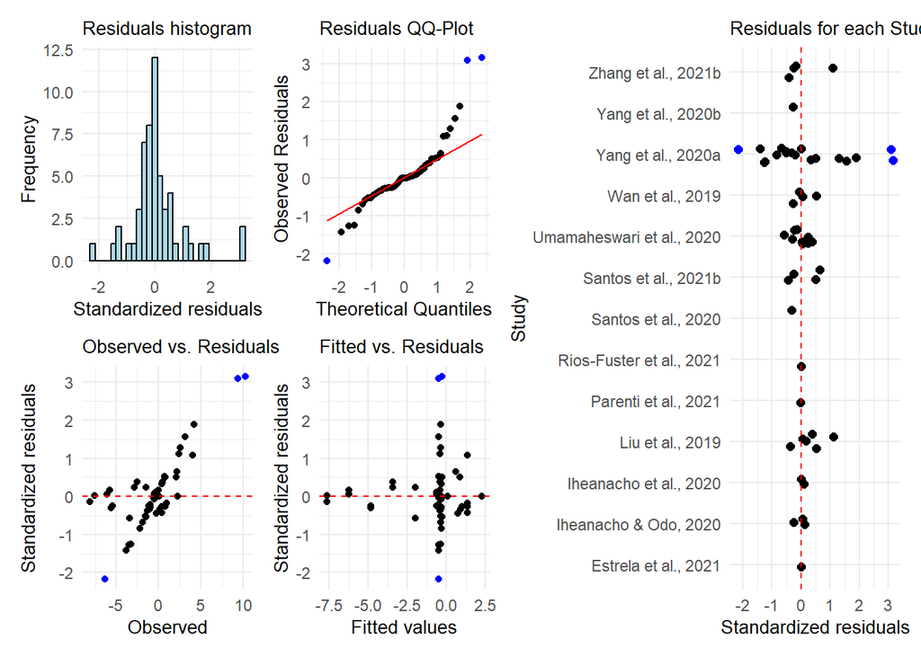

```r
diagnostic_plots(m)
```

#### Orchard plots

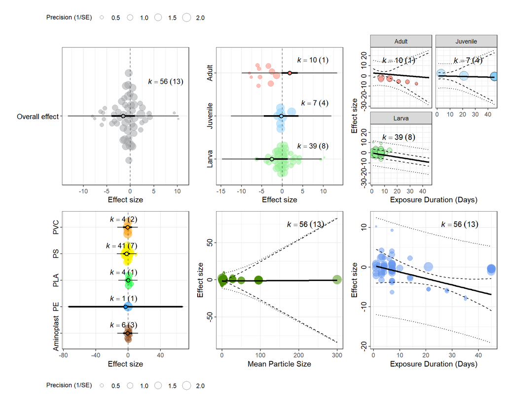

# Referências

Harrer, Mathias, Pim Cuijpers, Toshi A. Furukawa, and David D. Ebert. n.d. *Chapter 9 Publication Bias | Doing Meta-Analysis in R*. https://bookdown.org/MathiasHarrer/Doing_Meta_Analysis_in_R/pub-bias.html.

Nakagawa, Shinichi, Malgorzata Lagisz, Michael D. Jennions, Julia Koricheva, Daniel W. A. Noble, Timothy H. Parker, Alfredo Sánchez-Tójar, Yefeng Yang, and Rose E. O’Dea. 2022. “Methods for Testing Publication Bias in Ecological and Evolutionary Meta-Analyses.” *Methods in Ecology and Evolution* 13 (1): 4–21. https://doi.org/10.1111/2041-210X.13724.

Nakagawa, Shinichi, Malgorzata Lagisz, Rose E. O’Dea, Joanna Rutkowska, Yefeng Yang, Daniel W. A. Noble, and Alistair M. Senior. 2021. “The Orchard Plot: Cultivating a Forest Plot for Use in Ecology, Evolution, and Beyond.” *Research Synthesis Methods* 12 (1): 4–12. https://doi.org/10.1002/jrsm.1424.

Stanley, T. D. 2017. “Limitations of PET-PEESE and Other Meta-Analysis Methods.” *Social Psychological and Personality Science* 8 (5): 581–91. https://doi.org/10.1177/1948550617693062.

Viechtbauer, Wolfgang. 2010. “Conducting Meta-Analyses in R with the Metafor Package.” *Journal of Statistical Software* 36 (August): 1–48. https://doi.org/10.18637/jss.v036.i03.

———. 2022. “Konstantopoulos (2011) [the Metafor Package].” https://www.metafor-project.org/doku.php/analyses:konstantopoulos2011.

Viechtbauer, Wolfgang, and Mike W.-L. Cheung. 2010. “Outlier and Influence Diagnostics for Meta-Analysis.” *Research Synthesis Methods* 1 (2): 112–25. https://doi.org/10.1002/jrsm.11.

Yang, Yefeng, Malcolm Macleod, Jinming Pan, Malgorzata Lagisz, and Shinichi Nakagawa. 2023. “Advanced Methods and Implementations for the Meta-Analyses of Animal Models: Current Practices and Future Recommendations.” *Neuroscience & Biobehavioral Reviews* 146 (March): 105016. https://doi.org/10.1016/j.neubiorev.2022.105016.